← Niger drought AA← AA sécheresse Niger

# Niger 2026 — pockets of droughtNiger 2026 — poches de sécheresse

Analysis of 9 September 2026, covering the June–September rainy season. OCHA Centre for Humanitarian Data.Analyse du 9 septembre 2026, couvrant la saison des pluies de juin à septembre. Centre de données humanitaires de l’OCHA.

This page looks for areas of Niger where drought could be emerging in the 2026 season, by putting this year's observed rainfall (gridded products, the DMN's ENACTS analysis and rain gauges), vegetation stress (FAO ASI and the NDVI-based VHI) and the current skill-filtered SEAS5 seasonal forecast in the context of each indicator's own multi-decade record. Every indicator is expressed as an empirical return period (RP): a department at RP 10 is seeing a value that dry roughly once in 10 years. Humanitarian-needs severity from the 2026 HNRP is overlaid to show where climate signals coincide with the highest pre-existing needs.Cette page recherche les zones du Niger où une sécheresse pourrait se dessiner pendant la saison 2026, en replaçant les précipitations observées cette année (produits maillés, analyse ENACTS de la DMN et pluviomètres), le stress de la végétation (ASI de la FAO et VHI, dérivé du NDVI) et la prévision saisonnière SEAS5 filtrée selon la performance du modèle, dans le contexte de plusieurs décennies d’historique pour chaque indicateur. Chaque indicateur est exprimé en période de retour empirique (PR) : un département à PR 10 connaît une valeur aussi sèche environ une fois tous les 10 ans. La sévérité des besoins humanitaires du HNRP 2026 est superposée pour montrer où les signaux climatiques coïncident avec les besoins préexistants les plus élevés.

**Key findingsPrincipaux constats**

- Rainfall deficits are widespread: 29 of 67 departments at RP ≥ 5 years for June–July rainfall (CHIRPS) and 37 of 67 for June–August (IMERG). ENACTS reads −0.12 over the monitored zone — no trigger — yet its own department detail shows RP 5–9 pockets in eastern Diffa and southern Dosso.Les déficits pluviométriques sont étendus : 29 des 67 départements à PR ≥ 5 ans pour juin–juillet (CHIRPS) et 37 sur 67 pour juin–août (IMERG). ENACTS vaut −0,12 sur la zone suivie — seuil non atteint — mais son détail départemental montre des poches à PR 5–9 dans l’est de Diffa et le sud de Dosso.
- The combined indicator puts six departments in severe rainfall deficit (median rain RP ≥ 10): Keita, Dioundiou, Dosso, Gaya, Loga and Tanout, with 18 more on watch (Tahoua belt, rest of Dosso, the east). And vegetation has begun to confirm in the east: on the detrended VHI (the vegetation pillar — see methods), the Diffa region is at its worst late-August value of the 44-year record and Zinder crosses RP 5, putting seven departments in the compound class — Tanout (severe compound) plus the eastern belt from N'Gourti to N'Guigmi — exactly where the JRC ASAP system's unit-level warnings sit at level 3 (Diffa, Maïné-Soroa and Tanout croplands, 3+ on N'Guigmi rangelands).L’indicateur combiné place six départements en déficit pluviométrique sévère (PR pluie médiane ≥ 10) : Keita, Dioundiou, Dosso, Gaya, Loga et Tanout, et 18 autres en vigilance (bande de Tahoua, reste de Dosso, l’est). Et la végétation commence à confirmer à l’est : sur le VHI détendancé (le pilier végétation — voir méthodes), la région de Diffa est à sa pire valeur de fin août des 44 ans d’historique et Zinder franchit PR 5, plaçant sept départements en classe composée — Tanout (composé sévère) plus la bande orientale de N'Gourti à N'Guigmi — exactement là où les alertes ASAP (JRC), par unité, sont au niveau 3 (cultures de Diffa, Maïné-Soroa et Tanout, 3+ sur les pâturages de N'Guigmi).
- With July and August observed, the season-closing JAS estimate is the driest of the 46-year record in every region — though this leans on ERA5, which runs anomalously dry in 2026. The remaining pure forecast, SON from the September SEAS5 issuance, adds a moderate dry tilt for the harvest and pasture-regrowth window (18 departments at RP ≥ 5, skill-filtered).Juillet et août observés, l’estimation de clôture de saison JAS est la plus sèche de l’historique de 46 ans dans toutes les régions — mais elle repose sur ERA5, anormalement sec en 2026. La prévision pure restante, SON de l’émission SEAS5 de septembre, ajoute une tendance sèche modérée pour la fenêtre des récoltes et de la repousse des pâturages (18 départements à PR ≥ 5, filtrée selon la performance).
- Backtest: in early September the same composite flagged the 2009 CERF drought (24 departments in rainfall deficit, 20 compound), the 2011 western pockets and — with August observed — partially the 2004 season, but still misses 2021, whose rains only collapsed in September. 2026 matches 2009's rainfall extent at the same date (24 departments each) and its vegetation is starting to follow (17 departments at vegetation RP ≥ 5, vs 33 in 2009).Contre-épreuve : début septembre, le même composite signalait la sécheresse CERF de 2009 (24 départements en déficit pluviométrique, dont 20 en composé), les poches de l’ouest en 2011 et — août observé — partiellement la saison 2004, mais manque toujours 2021, dont les pluies ne se sont effondrées qu’en septembre. 2026 égale l’étendue pluviométrique de 2009 à la même date (24 départements chacun) et sa végétation commence à suivre (17 départements à PR végétation ≥ 5, contre 33 en 2009).
- The 4 HNRP severity-4 departments (N'Guigmi (Diffa), Bankilaré (Tillabéri), Téra (Tillabéri), Torodi (Tillabéri)) all show at least one rainfall signal at RP ≥ 5, but only N'Guigmi makes the composite list — now in the compound class (rainfall watch plus vegetation stress) — in western Tillabéri the deficit is seen by IMERG and the hybrid only.Les 4 départements en sévérité 4 du HNRP (N'Guigmi (Diffa), Bankilaré (Tillabéri), Téra (Tillabéri), Torodi (Tillabéri)) montrent tous au moins un signal pluviométrique à PR ≥ 5, mais seul N'Guigmi figure au composite — désormais en classe composée (vigilance pluie plus stress de la végétation) — dans l’ouest de Tillabéri, le déficit n’est vu que par IMERG et l’hybride.

## Combined drought indicatorIndicateur de sécheresse combiné

The indicators are combined into a single class per department, following the logic of combined drought indicators such as the JRC's: a rainfall pillar and a vegetation pillar. The rainfall pillar is the median dryness ranking of the four rainfall witnesses — the median of their exceedance probabilities, expressed as a return period (CHIRPS June–July, IMERG June–August, ENACTS June–July SPI, and the detrended SEAS5+ERA5 JAS hybrid) — the median demands majority agreement, so no single product (an ENACTS artifact, ERA5's dry bias) can drive the class alone. The vegetation pillar is the regional VHI return period computed on the linearly detrended series: both raw ASI and VHI carry strong long-term trends (re-greening plus the change of satellite era) that otherwise concentrate every extreme before 2000, and detrending the floor-bounded ASI is not valid, so the pillar rests on detrended VHI alone (raw ASI is kept as context in the table). Classes: rainfall watch (median rain RP 5–10), severe rainfall deficit (RP ≥ 10), and their compound counterparts when vegetation is also at RP ≥ 5 — the stage where a rainfall deficit is visibly hitting crops and pasture. On the maps, the fills show the rainfall pillar and vegetation stress is overlaid as dark-red hatching (diagonal: vegetation RP 5–10; cross-hatch: RP ≥ 10), so it reads as an aggravating signal wherever it appears. HNRP severity is drawn as purple outlines: thick solid for the four severity-4 departments, thin dashed for severity 3.Les indicateurs sont combinés en une classe unique par département, suivant la logique des indicateurs de sécheresse combinés comme celui du JRC : un pilier précipitations et un pilier végétation. Le pilier précipitations est le classement médian de sécheresse des quatre témoins pluviométriques — la médiane de leurs probabilités de dépassement, exprimée en période de retour (CHIRPS juin–juillet, IMERG juin–août, SPI juin–juillet ENACTS et hybride SEAS5+ERA5 JAS détendancé) — la médiane exige un accord majoritaire, de sorte qu’aucun produit isolé (un artefact ENACTS, le biais sec d’ERA5) ne peut déterminer la classe à lui seul. Le pilier végétation est la période de retour régionale du VHI calculée sur la série linéairement détendancée : l’ASI et le VHI bruts portent de fortes tendances de long terme (reverdissement et changement d’ère satellitaire) qui concentrent sinon tous les extrêmes avant 2000, et détendancer l’ASI, borné à zéro, n’est pas valide — le pilier repose donc sur le seul VHI détendancé (l’ASI brut reste en contexte dans le tableau). Classes : vigilance pluviométrique (PR médiane 5–10), déficit pluviométrique sévère (PR ≥ 10), et leurs équivalents composés lorsque la végétation est aussi à PR ≥ 5 — le stade où le déficit de pluie atteint visiblement cultures et pâturages. Sur les cartes, les aplats montrent le pilier pluie et le stress de la végétation est superposé en hachures rouge foncé (diagonales : végétation PR 5–10 ; croisées : PR ≥ 10), pour qu’il se lise comme un signal aggravant partout où il apparaît. La sévérité du HNRP est tracée en contours violets : trait plein épais pour les quatre départements en sévérité 4, tirets fins pour la sévérité 3.

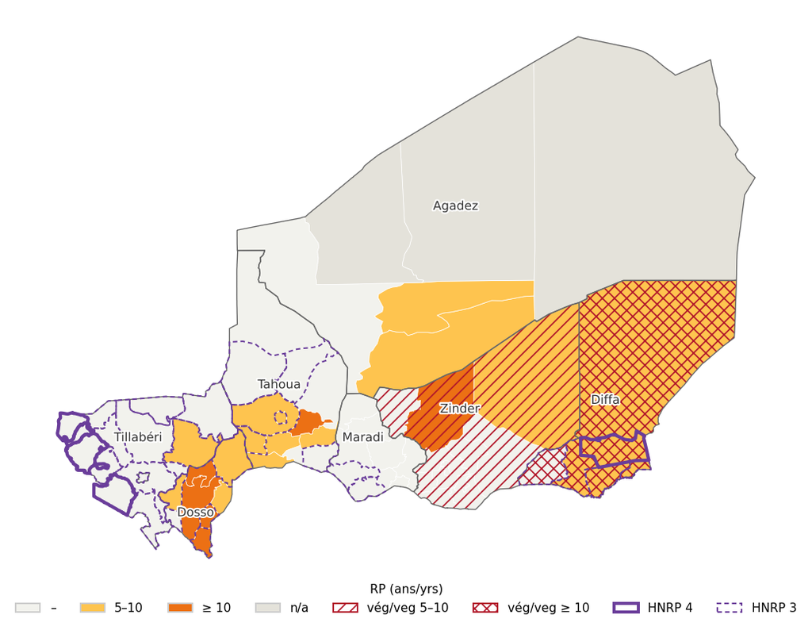

Combined drought indicator, 9 September 2026. Yellow/orange fills: median rainfall RP 5–10 / ≥ 10 years; dark-red hatching: vegetation pillar (detrended VHI) at RP 5–10 (diagonal) or ≥ 10 (cross-hatch) — hatching on a coloured fill is a compound department; pale grey n/a: Saharan departments outside ENACTS coverage (Arlit, Bilma, Iferouane), not assessed; purple outlines: HNRP 2026 intersectoral severity 4 (thick solid) and 3 (thin dashed).Indicateur de sécheresse combiné, 9 septembre 2026. Aplats jaunes/orange : PR pluviométrique médiane 5–10 / ≥ 10 ans ; hachures rouge foncé : pilier végétation (VHI détendancé) à PR 5–10 (diagonales) ou ≥ 10 (croisées) — des hachures sur un aplat coloré signalent un département en classe composée ; gris pâle n/a : départements sahariens hors couverture ENACTS (Arlit, Bilma, Iferouane), non évalués ; contours violets : sévérité intersectorielle 4 du HNRP 2026 (plein épais) et 3 (tirets fins).

| DepartmentDépartement | RegionRégion | CHIRPS Jun–Jul RPCHIRPS juin–juil. PR | IMERG Jun–Aug RPIMERG juin–août PR | ENACTS SPI RPENACTS SPI PR | SEAS5 JAS RPSEAS5 JAS PR | ASI RP*ASI PR* | VHI RP (detr.)*VHI PR (détend.)* | HNRP severitySévérité HNRP | People in needPersonnes dans le besoin | Rain RP (median)PR pluie (médiane) | ClassClasse |
| --- | --- | --- | --- | --- | --- | --- | --- | --- | --- | --- | --- |
| Tanout | Zinder | 7.8 | 15 | 2.6 | 46 | 2.2 | 5.5 | 1 | 0 | 10 | Severe compoundComposé sévère |
| N'Gourti | Diffa | 3.6 | 15 | 7.4 | 46 | 4.4 | 44 | 2 | 3 | 9.9 | CompoundComposé |
| Diffa | Diffa | 2.0 | 30 | 4.6 | 46 | 4.4 | 44 | 3 | 259,592 | 8.0 | CompoundComposé |
| Maïné Soroa | Diffa | 1.7 | 15 | 5.3 | 46 | 4.4 | 44 | 3 | 47,593 | 7.8 | CompoundComposé |
| N'Guigmi | Diffa | 2.9 | 30 | 4.1 | 23 | 4.4 | 44 | 4 | 66,654 | 7.0 | CompoundComposé |
| Tesker | Zinder | 2.9 | 10 | 5.3 | 46 | 2.2 | 5.5 | 1 | 0 | 6.9 | CompoundComposé |
| Bosso | Diffa | 2.5 | 30 | 3.1 | 23 | 4.4 | 44 | 3 | 38,296 | 5.4 | CompoundComposé |
| Keita | Tahoua | 24 | 10 | 2.8 | 46 | 1.7 | 4.9 | 1 | 569 | 14 | SevereSévère |
| Dioundiou | Dosso | 24 | 6.0 | 9.2 | 46 | 1.7 | 1.8 | 3 | 31,118 | 13 | SevereSévère |
| Dosso | Dosso | 16 | 10 | 1.9 | 46 | 1.7 | 1.8 | 1 | 0 | 12 | SevereSévère |
| Gaya | Dosso | 16 | 10 | 5.3 | 46 | 1.7 | 1.8 | 3 | 64,109 | 12 | SevereSévère |
| Loga | Dosso | 12 | 10 | 1.7 | 46 | 1.7 | 1.8 | 1 | 11,895 | 11 | SevereSévère |
| Illéla | Tahoua | 24 | 6.0 | 3.7 | 46 | 1.7 | 4.9 | 1 | 6,175 | 9.6 | WatchVigilance |
| Tibiri | Dosso | 24 | 5.0 | 1.8 | 46 | 1.7 | 1.8 | 1 | 377 | 8.2 | WatchVigilance |
| Ville de Tahoua | Tahoua | 24 | 5.0 | 2.1 | 46 | 1.7 | 4.9 | 1 | 3,428 | 8.2 | WatchVigilance |
| Dogondoutchi | Dosso | 12 | 6.0 | 1.3 | 46 | 1.7 | 1.8 | 3 | 95,534 | 7.9 | WatchVigilance |
| Bagaroua | Tahoua | 16 | 5.0 | 1.5 | 46 | 1.7 | 4.9 | 3 | 19,623 | 7.6 | WatchVigilance |
| Filingué | Tillabéri | 5.9 | 10 | 1.6 | 46 | 1.2 | 3.1 | 3 | 109,702 | 7.4 | WatchVigilance |
| Tahoua | Tahoua | 24 | 3.3 | 4.1 | 46 | 1.7 | 4.9 | 3 | 137,424 | 7.0 | WatchVigilance |
| Bouza | Tahoua | 9.4 | 5.0 | 1.4 | 46 | 1.7 | 4.9 | 1 | 305 | 6.5 | WatchVigilance |
| Aderbissinat | Agadez | 16 | 1.7 | 4.1 | 23 | 2.8 | 2.9 | 1 | 0 | 6.5 | WatchVigilance |
| Birni N'Konni | Tahoua | 12 | 3.8 | 2.2 | 46 | 1.7 | 4.9 | 1 | 4,351 | 5.7 | WatchVigilance |
| Boboye | Dosso | 3.6 | 10 | 1.2 | 46 | 1.7 | 1.8 | 3 | 100,883 | 5.3 | WatchVigilance |
| Tchirozerine | Agadez | 12 | 1.6 | 3.4 | 23 | 2.8 | 2.9 | 1 | 2,750 | 5.2 | WatchVigilance |
| Ingall | Agadez | 12 | 2.7 | 2.8 | 46 | 2.8 | 2.9 | 1 | 4,984 | 4.6 | –– |
| Bermo | Maradi | 4.7 | 4.3 | 1.5 | 46 | 1.9 | 2.1 | 1 | 42,978 | 4.5 | –– |
| Balleyara | Tillabéri | 2.4 | 30 | 1.9 | 46 | 1.2 | 3.1 | 3 | 33,364 | 4.4 | –– |
| Abala | Tillabéri | 7.8 | 3.0 | 1.4 | 46 | 1.2 | 3.1 | 3 | 78,236 | 4.3 | –– |
| Malbaza | Tahoua | 6.7 | 3.0 | 1.9 | 46 | 1.7 | 4.9 | 1 | 0 | 4.1 | –– |
| Falmey | Dosso | 3.4 | 5.0 | 1.1 | 46 | 1.7 | 1.8 | 3 | 38,000 | 4.0 | –– |
| Ayerou | Tillabéri | 1.7 | 15 | 2.3 | 46 | 1.2 | 3.1 | 3 | 65,931 | 4.0 | –– |
| Tessaoua | Maradi | 4.3 | 3.8 | 1.1 | 46 | 1.9 | 2.1 | 1 | 0 | 4.0 | –– |
| Tillia | Tahoua | 7.8 | 2.1 | 1.9 | 46 | 1.7 | 4.9 | 3 | 88,724 | 3.4 | –– |
| Tassara | Tahoua | 3.9 | 2.7 | 2.5 | 46 | 1.7 | 4.9 | 2 | 15,353 | 3.2 | –– |
| Tchintabaraden | Tahoua | 7.8 | 2.0 | 1.7 | 46 | 1.7 | 4.9 | 3 | 88,701 | 3.2 | –– |
| Bankilaré | Tillabéri | 1.7 | 15 | 1.5 | 46 | 1.2 | 3.1 | 4 | 35,651 | 3.1 | –– |
| Torodi | Tillabéri | 1.2 | 7.5 | 1.9 | 46 | 1.2 | 3.1 | 4 | 86,701 | 3.1 | –– |
| Say | Tillabéri | 1.8 | 10 | 1.3 | 46 | 1.2 | 3.1 | 3 | 80,821 | 3.1 | –– |
| Mayahi | Maradi | 3.4 | 2.7 | 1.1 | 46 | 1.9 | 2.1 | 1 | 0 | 3.0 | –– |
| Téra | Tillabéri | 1.6 | 10 | 1.8 | 23 | 1.2 | 3.1 | 4 | 226,192 | 3.0 | –– |
| Ouallam | Tillabéri | 1.7 | 10 | 1.6 | 46 | 1.2 | 3.1 | 3 | 150,080 | 3.0 | –– |
| Gazaoua | Maradi | 7.8 | 1.8 | 1.1 | 46 | 1.9 | 2.1 | 1 | 18,010 | 2.9 | –– |
| Banibangou | Tillabéri | 1.9 | 5.0 | 1.4 | 46 | 1.2 | 3.1 | 3 | 27,353 | 2.7 | –– |
| Madaoua | Tahoua | 5.9 | 1.7 | 1.3 | 46 | 1.7 | 4.9 | 3 | 252,952 | 2.6 | –– |
| Dakoro | Maradi | 2.5 | 2.7 | 1.2 | 46 | 1.9 | 2.1 | 1 | 0 | 2.6 | –– |
| Ville de Niamey | Niamey | 1.3 | 10 | 1.5 | 46 | 2.8 | 2.0 | 1 | 4,379 | 2.6 | –– |
| Madarounfa | Maradi | 3.9 | 1.9 | 1.2 | 46 | 1.9 | 2.1 | 3 | 126,082 | 2.5 | –– |
| Kollo | Tillabéri | 1.3 | 15 | 1.3 | 46 | 1.2 | 3.1 | 3 | 113,345 | 2.5 | –– |
| Abalak | Tahoua | 6.7 | 1.4 | 1.3 | 46 | 1.7 | 4.9 | 1 | 1,486 | 2.4 | –– |
| Tillabéri | Tillabéri | 1.4 | 5.0 | 1.4 | 23 | 1.2 | 3.1 | 3 | 80,290 | 2.2 | –– |
| Aguié | Maradi | 6.7 | 1.3 | 1.1 | 46 | 1.9 | 2.1 | 1 | 4,351 | 2.2 | –– |
| Ville de Maradi | Maradi | 3.1 | 1.7 | 1.1 | 46 | 1.9 | 2.1 | 1 | 15,994 | 2.2 | –– |
| Gothèye | Tillabéri | 1.3 | 4.3 | 1.4 | 46 | 1.2 | 3.1 | 3 | 115,659 | 2.1 | –– |
| Guidan Roumdji | Maradi | 3.4 | 1.3 | 1.1 | 46 | 1.9 | 2.1 | 3 | 246,830 | 1.9 | –– |
| Takeita | Zinder | 4.3 | 3.3 | 1.3 | 46 | 2.2 | 5.5 | 1 | 0 | 3.7 | VegetationVégétation |
| Dungass | Zinder | 2.2 | 7.5 | 1.4 | 46 | 2.2 | 5.5 | 1 | 0 | 3.4 | VegetationVégétation |
| Magaria | Zinder | 5.2 | 2.5 | 1.8 | 46 | 2.2 | 5.5 | 1 | 0 | 3.4 | VegetationVégétation |
| Kantché | Zinder | 7.8 | 2.1 | 1.3 | 46 | 2.2 | 5.5 | 1 | 210 | 3.4 | VegetationVégétation |
| Goudoumaria | Diffa | 1.4 | 6.0 | 2.3 | 46 | 4.4 | 44 | 3 | 38,044 | 3.3 | VegetationVégétation |
| Belbedji | Zinder | 4.7 | 2.3 | 1.8 | 23 | 2.2 | 5.5 | 1 | 0 | 3.1 | VegetationVégétation |
| Gouré | Zinder | 1.5 | 6.0 | 1.8 | 46 | 2.2 | 5.5 | 1 | 109 | 2.7 | VegetationVégétation |
| Mirriah | Zinder | 3.9 | 1.9 | 1.3 | 46 | 2.2 | 5.5 | 1 | 0 | 2.5 | VegetationVégétation |
| Damagaram Takaya | Zinder | 2.1 | 3.0 | 1.9 | 46 | 2.2 | 5.5 | 1 | 0 | 2.5 | VegetationVégétation |
| Ville de Zinder | Zinder | 2.9 | 1.8 | 1.5 | 46 | 2.2 | 5.5 | 1 | 7 | 2.2 | VegetationVégétation |
| Bilma | Agadez | 2.6 | 10 | – | 46 | 2.8 | 2.9 | 1 | 0 | 10 | n/an/a |
| Arlit | Agadez | 5.9 | 6.0 | – | 46 | 2.8 | 2.9 | 1 | 0 | 6.0 | n/an/a |
| Iferouane | Agadez | 4.3 | 2.7 | – | 46 | 2.8 | 2.9 | 1 | 0 | 4.3 | n/an/a |

Departments with at least one indicator at RP ≥ 5 or HNRP severity 4. * ASI/VHI are only available per region (FAO GAUL admin-1); the regional value is shown for each department. The VHI RP is computed on the detrended series (the combined indicator's vegetation pillar); the ASI RP is on the raw series, context only. ENACTS is blank for Saharan departments without coverage. SEAS5 (the detrended SEAS5+ERA5 JAS hybrid) is blank where the model has insufficient historical performance (r < 0.30).Départements avec au moins un indicateur à PR ≥ 5 ou en sévérité 4 du HNRP. * L’ASI et le VHI ne sont disponibles que par région (admin-1 GAUL de la FAO) ; la valeur régionale est reprise pour chaque département. La PR du VHI est calculée sur la série détendancée (le pilier végétation de l’indicateur combiné) ; la PR de l’ASI est sur la série brute, à titre de contexte. ENACTS est vide pour les départements sahariens sans couverture. SEAS5 (l’hybride SEAS5+ERA5 JAS détendancé) est vide lorsque la performance historique du modèle est insuffisante (r < 0,30).

## The same picture, every season since 1991La même image, chaque saison depuis 1991

As a reality check, the identical composite is reconstructed for every season since 1991, each panel using only what was observable in early September of that year (after that September's SEAS5 issuance). Red frames mark the growing seasons that later drew a CERF drought allocation — mapped to the season the drought actually occurred in, not the allocation date: the January–August 2010 allocations respond to the failed 2009 season, the November 2011 and April 2012 ones to the 2011 season, and the December 2021 food-security allocation to the 2021 season ('cereal yields down 39% … lower-than-normal rainfall'). A small September 2008 allocation is typed 'Drought' in the CERF records, but its projects (a Zinder nutrition scale-up, child-nutrition support, humanitarian air services, FAO support against rising food and input prices) show it answered the 2008 food-price crisis, not a failed season — it is left unframed. The 2022 anticipatory-action allocation (dashed frame) is excluded — it was triggered by the framework, not a conventional response. The strong unframed years carry their own story: 1993 and 1995–1997 are documented poor seasons that predate CERF (created 2006), and 2006's eastern signal — Tanout, Zinder and Diffa at their driest in three of the four witnesses, with heavy vegetation stress — drew no drought-typed CERF response. All panels are reconstructed with today's datasets; before 1998 the rain pillar rests on three witnesses (no IMERG).Comme contre-épreuve, le même composite est reconstruit pour chaque saison depuis 1991, chaque panneau n’utilisant que ce qui était observable début septembre de l’année concernée (après l’émission SEAS5 de septembre). Les cadres rouges marquent les saisons agricoles ayant ensuite donné lieu à une allocation CERF pour sécheresse — rattachées à la saison où la sécheresse a réellement eu lieu, pas à la date de l’allocation : les allocations de janvier–août 2010 répondent à la saison 2009 échouée, celles de novembre 2011 et d’avril 2012 à la saison 2011, et l’allocation sécurité alimentaire de décembre 2021 à la saison 2021 (« rendements céréaliers en baisse de 39 % … précipitations inférieures à la normale »). Une petite allocation de septembre 2008 est typée « sécheresse » dans les registres CERF, mais ses projets (renforcement nutritionnel à Zinder, nutrition infantile, services aériens humanitaires, appui FAO face à la hausse des prix des denrées et des intrants) montrent qu’elle répondait à la crise des prix alimentaires de 2008, pas à une saison échouée — elle n’est pas encadrée. L’allocation d’action anticipatoire de 2022 (cadre en tirets) est exclue — déclenchée par le cadre, ce n’est pas une réponse classique. Les années fortes sans cadre portent leur propre histoire : 1993 et 1995–1997 sont des saisons médiocres documentées antérieures au CERF (créé en 2006), et le signal de l’est en 2006 — Tanout, Zinder et Diffa à leur plus sec dans trois des quatre témoins, avec un fort stress de la végétation — n’a donné lieu à aucune réponse CERF de type sécheresse. Tous les panneaux sont reconstruits avec les jeux de données d’aujourd’hui ; avant 1998, le pilier pluie repose sur trois témoins (pas d’IMERG).

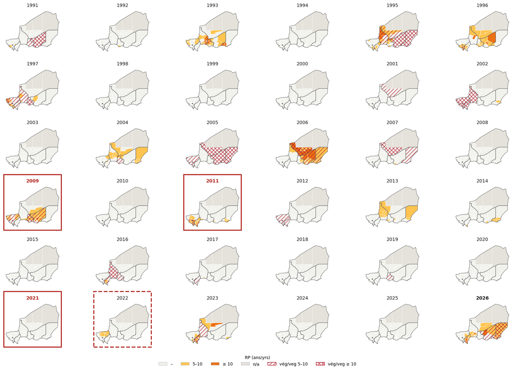

The combined drought indicator as it would have stood in early September of every season, 1991–2026. Solid red frames: seasons that drew a CERF drought allocation; dashed frame: the 2022 AA activation (excluded from the backtest set); bold: 2026.L’indicateur de sécheresse combiné tel qu’il se serait présenté début septembre de chaque saison, 1991–2026. Cadres rouges pleins : saisons ayant donné lieu à une allocation CERF pour sécheresse ; cadre en tirets : l’activation AA de 2022 (exclue de la contre-épreuve) ; en gras : 2026.

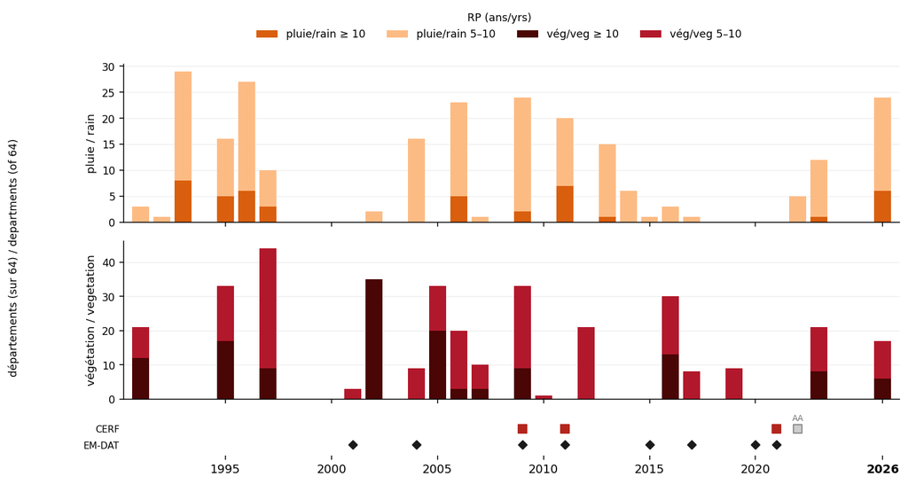

The same record as a summary series: per season, the number of assessed departments (of 64) whose rain pillar sits at RP ≥ 5 (dark: ≥ 10) and, below, whose vegetation pillar (detrended regional VHI, late-August dekad) sits at RP ≥ 5 (dark: ≥ 10). The marker strip flags the CERF drought seasons (red squares; the 2022 AA activation grey) and EM-DAT drought events since 2000 (black diamonds), each attributed to the growing season inside its window that the framework's severity list ranks worst. 2026's rainfall count is the largest since 2009–2011; its vegetation count (17 departments) is still well below 2009's 33, but unlike most of the noisy vegetation-only years it coincides with the rainfall deficit in a single eastern belt — hence the compound classes above.Le même historique en série résumée : par saison, le nombre de départements évalués (sur 64) dont le pilier pluie est à PR ≥ 5 (foncé : ≥ 10) et, en dessous, dont le pilier végétation (VHI régional détendancé, décade fin août) est à PR ≥ 5 (foncé : ≥ 10). Le bandeau de repères signale les saisons de sécheresse CERF (carrés rouges ; l'activation AA de 2022 en gris) et les événements de sécheresse EM-DAT depuis 2000 (losanges noirs), chacun rattaché à la saison agricole de sa fenêtre que la liste de sévérité du cadre classe la pire. Le décompte pluviométrique de 2026 est le plus élevé depuis 2009–2011 ; son décompte végétation (17 départements) reste bien sous les 33 de 2009, mais contrairement à la plupart des années « végétation seule », bruitées, il coïncide avec le déficit de pluie dans une même bande orientale — d'où les classes composées ci-dessus.

## Observed rainfall — CHIRPS, IMERG and ENACTSPrécipitations observées — CHIRPS, IMERG et ENACTS

Three witnesses of the season so far, each shown rather than averaged. CHIRPS (gauge-calibrated satellite, 1981–2026, final product through July) is driest over the Tahoua–Dosso belt; IMERG (satellite-only, 1998–2026, through 30 August) is driest over eastern Diffa and western Tillabéri; and ENACTS — the DMN's own gauge + satellite analysis behind the framework's observational trigger, pulled per department from the IRI Maproom (June–July SPI, 1991–2026) — flags eastern Diffa (Maïné-Soroa, N'Gourti) and southern Dosso (Dioundiou SPI −1.3, Gaya −1.0) while reading the Tahoua belt as near-normal. Over the monitored zone as a whole ENACTS reads −0.12 — far from the −0.71 trigger threshold — even though its own department detail contains 1-in-5 to 1-in-9-year pockets.Trois témoins de la saison à ce stade, montrés côte à côte plutôt que moyennés. CHIRPS (satellite calé sur les pluviomètres, 1981–2026, produit final jusqu’à juillet) est le plus sec sur la bande Tahoua–Dosso ; IMERG (satellitaire, 1998–2026, jusqu’au 30 août) est le plus sec sur l’est de Diffa et l’ouest de Tillabéri ; et ENACTS — l’analyse pluviomètres + satellite de la DMN qui alimente le déclencheur observationnel du cadre, extraite par département depuis le Maproom de l’IRI (SPI juin–juillet, 1991–2026) — signale l’est de Diffa (Maïné-Soroa, N'Gourti) et le sud de Dosso (Dioundiou SPI −1,3, Gaya −1,0) tout en lisant la bande de Tahoua comme proche de la normale. Sur l’ensemble de la zone suivie, ENACTS vaut −0,12 — loin du seuil de déclenchement de −0,71 — alors même que son propre détail départemental contient des poches de 1 an sur 5 à 1 an sur 9.

ERA5 (fourth panel) independently puts much of the same Tahoua–Dosso belt — and now, with August observed, 59 of 67 departments — at their driest or second-driest June–August of the 1981–2026 record. ERA5 is the weakest of the witnesses against station data historically and has run anomalously dry over Niger in 2026, which is why it is shown for corroboration but kept out of the combined indicator's rain pillar (its July already enters through the SEAS5+ERA5 hybrid).ERA5 (quatrième panneau) place indépendamment une grande partie de la même bande Tahoua–Dosso — et désormais, août observé, 59 des 67 départements — à leur juin–août le plus sec ou deuxième plus sec de l’historique 1981–2026. ERA5 est historiquement le moins fiable des témoins face aux données de stations et s’est montré anormalement sec sur le Niger en 2026, raison pour laquelle il est montré à titre de corroboration mais tenu à l’écart du pilier pluie de l’indicateur combiné (son mois de juillet y entre déjà via l’hybride SEAS5+ERA5).

ENACTS caveat: over a few departments the MON series shows a step change after 2021 that looks like an artifact of the thinning DMN station network (post-2021 mean SPI 1.2–1.5σ below the 1991–2020 mean in Gaya, Balleyara and Dioundiou — in 2022 ENACTS read Gaya as its 2nd-driest year while both the town gauge and CHIRPS recorded a wet season). Where gauges dropped out of the MON run, the product leans on its satellite background, whose local climatology differs from the gauge-anchored years the SPI was fitted on. ENACTS magnitudes in these departments are therefore likely overstated, even where the dry direction is corroborated by CHIRPS and IMERG.Réserve sur ENACTS : sur quelques départements, la série MON présente une rupture après 2021 qui ressemble à un artefact de l’amincissement du réseau de stations de la DMN (SPI moyen post-2021 de 1,2 à 1,5σ sous la moyenne 1991–2020 à Gaya, Balleyara et Dioundiou — en 2022, ENACTS lisait Gaya comme sa 2ᵉ année la plus sèche alors que le pluviomètre de la ville et CHIRPS enregistraient une saison humide). Là où des stations sont sorties de l’analyse MON, le produit s’appuie sur son fond satellitaire, dont la climatologie locale diffère des années ancrées sur les pluviomètres ayant servi à l’ajustement du SPI. Les amplitudes ENACTS dans ces départements sont donc probablement surestimées, même là où la direction sèche est corroborée par CHIRPS et IMERG.

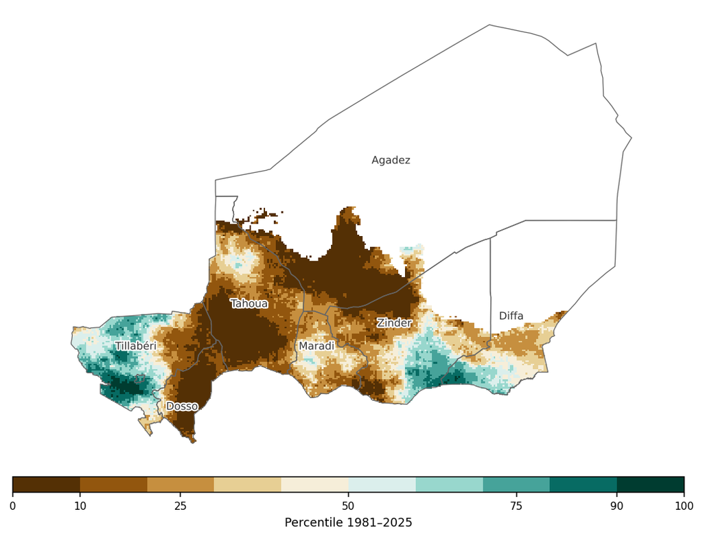

Percentile of the 2026 June–July rainfall total within 1981–2025, per CHIRPS 0.05° pixel. Brown = dry, green = wet; pixels with a June–July climatology under 40 mm (Saharan north) are masked.Percentile du cumul juin–juillet 2026 au sein de 1981–2025, par pixel CHIRPS 0,05°. Brun = sec, vert = humide ; les pixels dont la climatologie juin–juillet est inférieure à 40 mm (nord saharien) sont masqués.

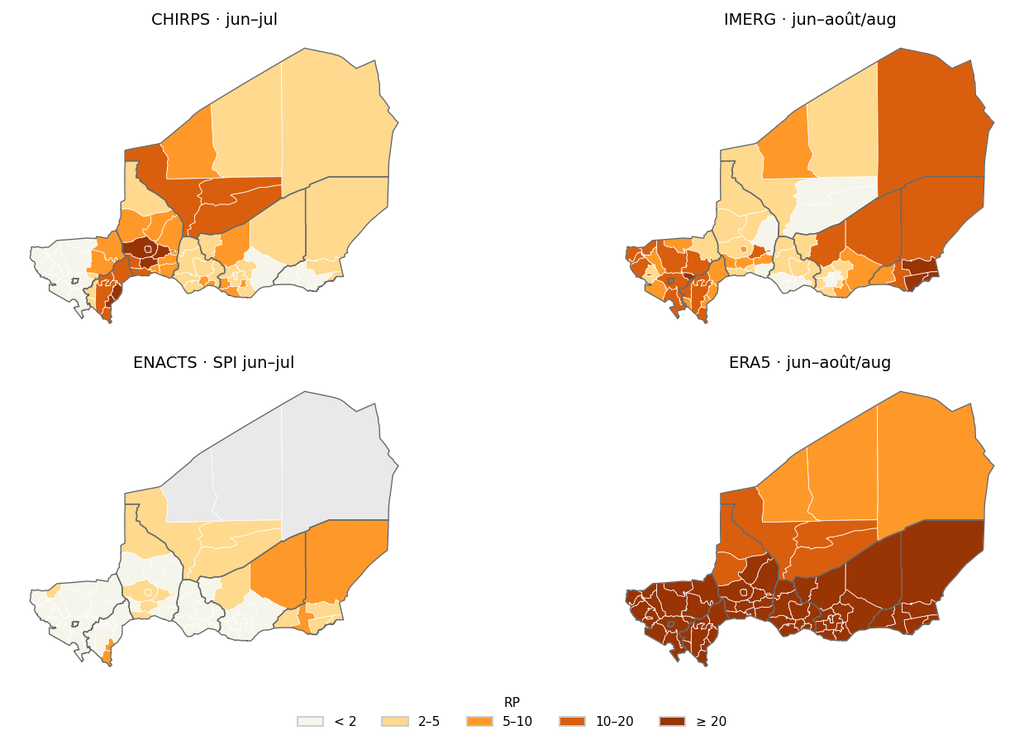

## Observed rainfall — rain gaugesPrécipitations observées — pluviomètres

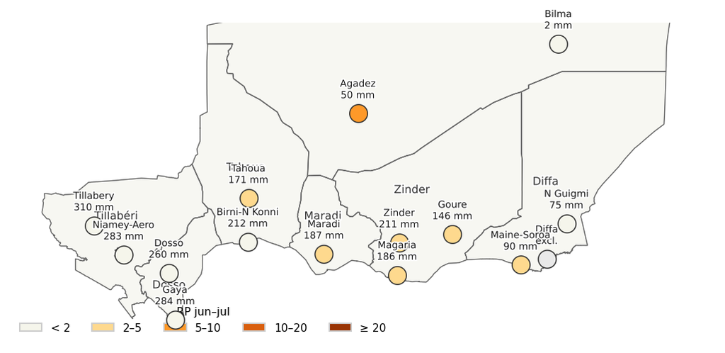

June–July 2026 gauge totals, coloured by return period within each station's 2008–2026 record.Cumuls juin–juillet 2026 aux stations, colorés par période de retour au sein de l’historique 2008–2026 de chaque station.

| StationStation | Jun–Jul 2026 (mm)Juin–juil. 2026 (mm) | Dry rankRang sec | RP (yrs)PR (ans) | Aug 2026 (mm)Août 2026 (mm) | Aug Q (DMN)Q août (DMN) | JJA dry rankRang sec JJA | JJA RP (yrs)PR JJA (ans) |
| --- | --- | --- | --- | --- | --- | --- | --- |
| Agadez (61024) | 50 | 2/9 | 5.0 | 107 | 5 | 3/7 | 2.7 |
| Magaria (61091) | 186 | 3/11 | 4.0 | 325 | 5 | 8/9 | 1.2 |
| Maine-Soroa (61096) | 90 | 4/11 | 3.0 | 82 | 1 | 2/7 | 4.0 |
| Goure (61045) | 146 | 5/12 | 2.6 | 110 | 2 | 2/8 | 4.5 |
| Tahoua (61043) | 171 | 5/10 | 2.2 | 117 | 6 | 3/8 | 3.0 |
| Zinder (61090) | 211 | 5/10 | 2.2 | 93 | 1 | 2/8 | 4.5 |
| Maradi (61080) | 187 | 6/12 | 2.2 | 152 | 2 | 4/10 | 2.8 |
| Gaya (61099)† | 284† | 7/12 | 1.9 | 202 | 6 | 3/9 | 3.3 |
| N Guigmi (61049) | 75 | 8/12 | 1.6 | 28 | 5 | 2/9 | 5.0 |
| Birni-N Konni (61075) | 212 | 8/12 | 1.6 | 126 | 1 | 6/10 | 1.8 |
| Bilma (61017) | 2 | 9/13 | 1.6 | 7 | 4 | 9/12 | 1.4 |
| Dosso (61053) | 260 | 7/9 | 1.4 | 104 | 2 | 2/6 | 3.5 |
| Niamey-Aero (61052) | 283 | 11/13 | 1.3 | 188 | 3 | 9/10 | 1.2 |
| Tillabery (61036) | 310 | 10/10 | 1.1 | 176 | 4 | 8/8 | 1.1 |
| Diffa (61085) | – | – | – | 51 | 1 | – | – |

Q = DMN's own quintile code for the month against its 30-year normal (1 = driest quintile, 5 = wettest; 0/6 = beyond the reference range).Q = code quintile de la DMN pour le mois par rapport à sa normale trentenaire (1 = quintile le plus sec, 5 = le plus humide ; 0/6 = hors de la plage de référence).

Diffa's July 2026 CLIMAT report transmitted 447 mm in 4 rain days — inconsistent with the station's own synoptic reports (≈ 27 mm), with gauge-calibrated CHIRPS at the town (≈ 88 mm) and with every other drought signal in the department. It is treated as a transmission error and excluded, so Diffa shows no 2026 gauge value here.Le message CLIMAT de Diffa pour juillet 2026 transmet 447 mm en 4 jours de pluie — incohérent avec les propres messages synoptiques de la station (≈ 27 mm), avec CHIRPS, calé sur les pluviomètres, à la ville (≈ 88 mm) et avec tous les autres signaux de sécheresse du département. Il est traité comme une erreur de transmission et exclu ; Diffa n’affiche donc pas de valeur pluviométrique 2026 ici.  
† Gaya's near-normal 2026 total rests entirely on its June report (163 mm — jointly the wettest June of its own archive), which CHC's station screening rejected from the CHIRPS June blend and which sits well above the satellite estimate at the town (131 mm). Its July report (121 mm, about a third below the local July climatology) was accepted by CHC and corroborates the dryness. The value is kept but should be read with caution.† Le cumul 2026 proche de la normale à Gaya repose entièrement sur son message de juin (163 mm — à égalité le juin le plus humide de sa propre archive), que le contrôle qualité de CHC a rejeté du mélange CHIRPS de juin et qui se situe bien au-dessus de l’estimation satellitaire à la ville (131 mm). Son message de juillet (121 mm, environ un tiers sous la climatologie locale de juillet) a été accepté par CHC et corrobore la sécheresse. La valeur est conservée mais à lire avec prudence.

## Vegetation — FAO ASI and VHIVégétation — ASI et VHI de la FAO

The FAO Agricultural Stress Index (ASI) is the share of cropland with a vegetation health index below 35 during the growing season; VHI combines NDVI-based vegetation condition with thermal stress. Both are shown for the latest dekad (21–31 August 2026) against the same dekad in every year since 1984.L’indice de stress agricole (ASI) de la FAO est la part des terres cultivées dont l’indice de santé de la végétation est inférieur à 35 pendant la campagne ; le VHI combine l’état de la végétation dérivé du NDVI et le stress thermique. Les deux sont montrés pour la dernière décade (21–31 août 2026) face à la même décade de chaque année depuis 1984.

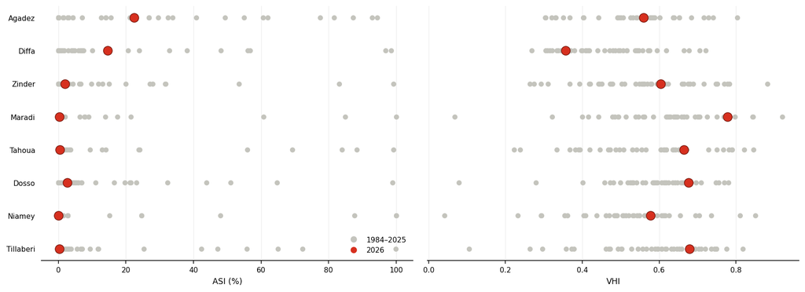

Region values for the 21–31 August dekad: grey = 1984–2025, red = 2026. High ASI is bad (more stressed cropland); low VHI is bad.Valeurs régionales pour la décade du 21–31 août : gris = 1984–2025, rouge = 2026. Un ASI élevé est défavorable (plus de cultures stressées) ; un VHI bas est défavorable.

Both raw series carry strong long-term trends — ASI falling 6–12 points per decade and VHI rising 0.02–0.08 per decade, a mix of the Sahel's re-greening and the change of satellite era — so on the raw values nearly every extreme lands before 2000 and a dry 2026 can still rank mid-pack. The combined indicator's vegetation pillar therefore uses the linearly detrended VHI (same convention as the SEAS5 hybrid); detrending the ASI, bounded at 0% stressed cropland, would manufacture artificial stress in wet regions and is not used. On the detrended VHI, 2026 is Diffa's worst late-August dekad of the 44-year record, with Zinder at RP 5.5 and Tahoua at RP 4.9.Les deux séries brutes portent de fortes tendances de long terme — l’ASI baisse de 6 à 12 points par décennie et le VHI monte de 0,02 à 0,08 par décennie, entre reverdissement du Sahel et changement d’ère satellitaire — si bien que sur les valeurs brutes presque tous les extrêmes tombent avant 2000 et qu’un 2026 sec peut rester au milieu du classement. Le pilier végétation de l’indicateur combiné utilise donc le VHI linéairement détendancé (même convention que l’hybride SEAS5) ; détendancer l’ASI, borné à 0 % de cultures stressées, fabriquerait un stress artificiel dans les régions humides et n’est pas retenu. Sur le VHI détendancé, 2026 est la pire décade de fin août de Diffa sur les 44 ans d’historique, avec Zinder à PR 5,5 et Tahoua à PR 4,9.

[figure not shown]

[figure not shown]

FAO GIEWS/ASIS maps for the 21–31 August 2026 dekad. Left: NDVI anomaly vs the long-term average (brown/red = below normal) — note the deficits along the southern agricultural belt of Zinder/Maradi and the far south-east (Diffa). Right: ASI per GAUL-2 area — south-eastern Diffa shows 25–40% of cropland stressed. Source: FAO GIEWS Earth Observation (open data).Cartes FAO GIEWS/ASIS pour la décade du 21–31 août 2026. Gauche : anomalie de NDVI par rapport à la moyenne de long terme (brun/rouge = sous la normale) — noter les déficits le long de la bande agricole sud de Zinder/Maradi et l’extrême sud-est (Diffa). Droite : ASI par zone GAUL-2 — le sud-est de Diffa montre 25–40 % de cultures stressées. Source : FAO GIEWS Earth Observation (données ouvertes).

### Cross-check: JRC ASAP warningsContre-vérification : alertes ASAP du JRC

The EC/JRC ASAP system (a separate product from FAO's ASIS) issues automated agricultural-drought warnings every dekad per admin unit and land cover, combining water-balance and biomass indicators. Its current classification corroborates — and sharpens — the picture: warnings on 29 of Niger's 35 assessed units (cropland and/or rangeland), with the Dosso–Tahoua–Tillabéri belt at level 1/1+ and, crucially, level-3 warnings (water balance AND biomass: poor growth with negative prospects) on Diffa, Maïné-Soroa and Tanout croplands and level 3+ on N'Guigmi rangelands. At ASAP's unit scale, the biomass impact in the east that the region-level ASI aggregate dilutes is already visible.Le système ASAP de la CE/JRC (un produit distinct de l'ASIS de la FAO) émet chaque décade des alertes automatiques de sécheresse agricole par unité administrative et type de couvert, en combinant bilan hydrique et biomasse. Sa classification actuelle corrobore — et affine — le tableau : alertes sur 29 des 35 unités évaluées du Niger (cultures et/ou pâturages), la bande Dosso–Tahoua–Tillabéri en niveau 1/1+, et surtout des alertes de niveau 3 (bilan hydrique ET biomasse : croissance médiocre et perspectives négatives) sur les cultures de Diffa, Maïné-Soroa et Tanout, et de niveau 3+ sur les pâturages de N'Guigmi. À l'échelle des unités ASAP, l'impact sur la biomasse à l'est — que l'agrégat régional de l'ASI dilue — est déjà visible.

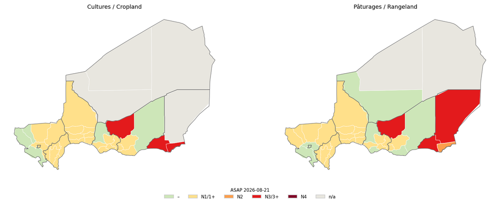

Reproduction of the current JRC ASAP warning classification for Niger (GAUL2 units × land cover, dekad of 21–31 August 2026; pulled from ASAP's public WFS). Grey: insufficient crop/rangeland area. Source: EC/JRC ASAP, agricultural-production-hotspots.ec.europa.eu.Reproduction de la classification d'alerte ASAP (JRC) actuelle pour le Niger (unités GAUL2 × couvert, décade du 21–31 août 2026 ; extraite du WFS public d'ASAP). Gris : superficie cultivée/pastorale insuffisante. Source : ASAP CE/JRC, agricultural-production-hotspots.ec.europa.eu.

## End-of-season outlook — SEAS5+ERA5 hybrid, skill-filteredPerspective de fin de saison — hybride SEAS5+ERA5, filtré selon la performance

Following the team's SEAS5 skill methodology, the outlook is the combined SEAS5+ERA5 hybrid: for JAS, July and August now come from ERA5 observations and September from the September-issued ECMWF SEAS5 forecast, each forecast month bias-corrected against ERA5 before blending. The hybrid is normalized to the ERA5 distribution and both forecast and observations are linearly detrended in log space (the skill explorer's usual Detrended variant), so the 2026 position is measured against the trend-adjusted climate rather than inflated by the Sahel's recent wetting trend. Values are only shown where the detrended historical performance is adequate (Pearson r ≥ 0.30 over 45 hindcast years; blank otherwise). With two of its three months observed, the JAS hybrid now reads as a season-closing estimate rather than a forecast — and it leans heavily on ERA5, so its uniformly extreme reading (driest-on-record everywhere) carries ERA5's 2026 dry anomaly and should be read alongside the gauge-anchored witnesses above. SON is the remaining pure forecast: the September issuance's outlook for September–November, the harvest and pasture-regrowth window.Suivant la méthodologie d’évaluation de SEAS5 de l’équipe, la perspective est l’hybride combiné SEAS5+ERA5 : pour JAS, juillet et août proviennent désormais des observations ERA5 et septembre de la prévision SEAS5 (CEPMMT) émise en septembre, chaque mois prévu étant corrigé de son biais par rapport à ERA5 avant combinaison. L’hybride est normalisé sur la distribution d’ERA5 et prévision comme observations sont détendancées linéairement en espace log (la variante Détendancée habituelle de l’explorateur de performance), de sorte que la position de 2026 se mesure par rapport au climat corrigé de la tendance, plutôt que gonflée par le récent verdissement du Sahel. Les valeurs ne sont montrées que là où la performance historique détendancée est suffisante (r de Pearson ≥ 0,30 sur 45 années de re-prévisions ; vide sinon). Avec deux de ses trois mois observés, l’hybride JAS se lit désormais comme une estimation de clôture de saison plutôt que comme une prévision — et il repose lourdement sur ERA5, de sorte que sa lecture uniformément extrême (le plus sec de l’historique partout) porte l’anomalie sèche 2026 d’ERA5 et doit être lue à la lumière des témoins ancrés sur les pluviomètres ci-dessus. SON est la prévision pure restante : la perspective de l’émission de septembre pour septembre–novembre, la fenêtre des récoltes et de la repousse des pâturages.

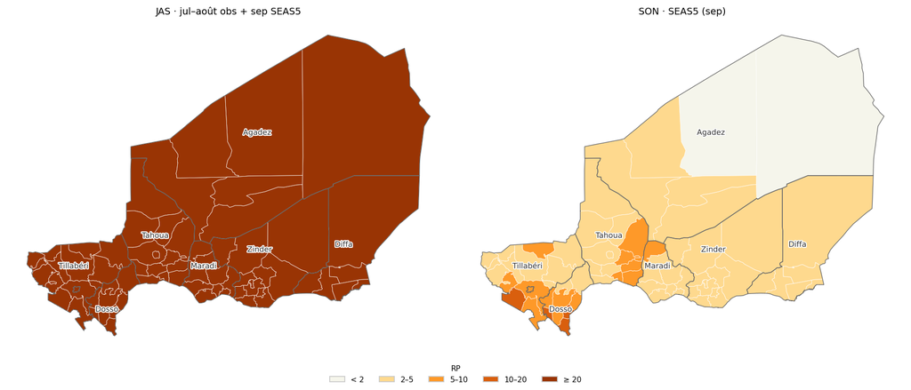

Return period of the detrended 2026 value within the detrended 1981–2025 hindcast distribution (dry tail), issued September 2026. Left: JAS season-closing hybrid (ERA5 July–August + SEAS5 September). Right: SON, the pure September forecast.Période de retour de la valeur 2026 détendancée dans la distribution des re-prévisions 1981–2025 détendancées (queue sèche), émission de septembre 2026. Gauche : hybride de clôture de saison JAS (juillet–août ERA5 + septembre SEAS5). Droite : SON, la prévision pure de septembre.

## Humanitarian needs (2026 HNRP)Besoins humanitaires (HNRP 2026)

The 2026 Niger HNRP's JIAF intersectoral severity per department (1 = minimal … 5 = catastrophic; Niger's 2026 analysis assigns up to class 4). The four class-4 departments — N'Guigmi (Diffa) and Bankilaré, Téra, Torodi (Tillabéri) — all sit inside 2026 drought pockets: N'Guigmi has the single driest IMERG June–August on record and Téra / Bankilaré combine rainfall deficits with the dry JAS outlook.Sévérité intersectorielle JIAF du HNRP 2026 du Niger par département (1 = minimale … 5 = catastrophique ; l’analyse 2026 du Niger atteint la classe 4). Les quatre départements en classe 4 — N'Guigmi (Diffa) et Bankilaré, Téra, Torodi (Tillabéri) — se trouvent tous dans des poches de sécheresse 2026 : N'Guigmi enregistre le juin–août IMERG le plus sec de l’historique et Téra / Bankilaré combinent déficits pluviométriques et perspective JAS sèche.

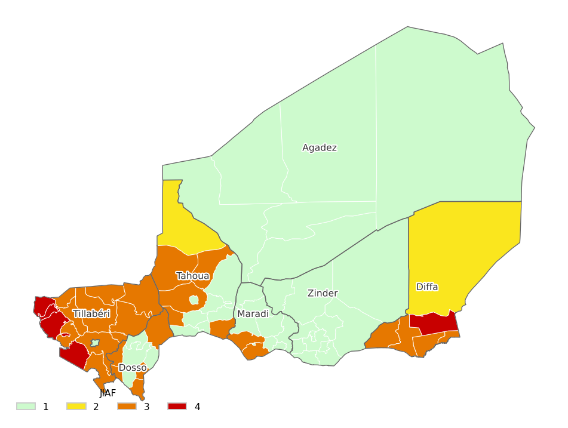

2026 HNRP JIAF intersectoral final severity by department. Source: OCHA HPC / JIAF workbook via the team's HPC mirror.Sévérité intersectorielle finale JIAF du HNRP 2026 par département. Source : HPC OCHA / classeur JIAF via le miroir HPC de l’équipe.

## Method and sourcesMéthode et sources

- Return periods: Weibull plotting position — the 2026 value is ranked within the indicator's full record including 2026 (rank 1 = most drought-like) and RP = (n+1)/rank. A short record caps the largest expressible RP (IMERG: 30, gauges: ~20), so identical colours can understate rarity for short-record indicators.Périodes de retour : position de tracé de Weibull — la valeur 2026 est classée dans l’historique complet de l’indicateur, 2026 inclus (rang 1 = le plus sec), et PR = (n+1)/rang. Un historique court plafonne la plus grande PR exprimable (IMERG : 30, pluviomètres : ~20) ; à couleur identique, la rareté peut donc être sous-estimée pour les indicateurs à historique court.
- ENACTS MON June–July SPI per department from the IRI fbfmaproom export API (DMN gauge + satellite analysis, 1991–2026; the MON series is revised as the record extends, so values can shift between pulls); CHIRPS v2.0 Africa monthly (CHC, final through July 2026); IMERG daily zonal means from the team raster-stats pipeline (fixed 1 Jun–30 Aug window); ERA5/SEAS5 monthly zonal means from the team database (ERA5 through Aug 2026, SEAS5 issued 1 Sep 2026); FAO GIEWS/ASIS dekadal ASI & VHI per region (through 31 Aug 2026); JRC ASAP warnings via the ASAP public WFS (dekad 21–31 Aug 2026); OGIMET CLIMAT gauge archive (2008–2026); HNRP severity and PiN from the OCHA HPC mirror (2026 plan).SPI juin–juillet ENACTS MON par département via l’API d’export du fbfmaproom de l’IRI (analyse pluviomètres + satellite de la DMN, 1991–2026 ; la série MON est révisée à mesure que l’historique s’allonge, les valeurs peuvent donc bouger d’une extraction à l’autre) ; CHIRPS v2.0 Afrique mensuel (CHC, final jusqu’à juillet 2026) ; moyennes zonales journalières IMERG du pipeline raster-stats de l’équipe (fenêtre fixe 1ᵉʳ juin–30 août) ; moyennes zonales mensuelles ERA5/SEAS5 de la base de l’équipe (ERA5 jusqu’à août 2026, SEAS5 émis le 1ᵉʳ septembre 2026) ; alertes ASAP (JRC) via le WFS public d'ASAP (décade 21–31 août 2026) ; ASI et VHI décadaires FAO GIEWS/ASIS par région (jusqu’au 31 août 2026) ; archive CLIMAT d’OGIMET pour les pluviomètres (2008–2026) ; sévérité et PiN du HNRP via le miroir HPC de l’OCHA (plan 2026).
- Combined indicator: rain pillar = median of the four rainfall witnesses' exceedance probabilities (each the Weibull rank within its own record; the hybrid ranked against all other hindcast years), converted back to a return period; vegetation pillar = RP of the linearly detrended regional VHI at the late-August dekad (raw ASI shown as context only). CERF allocations from the OCHA CERF records (aa.cerf_allocation mirror), drought-typed applications mapped to their valid growing season; the September 2008 'drought' allocation is excluded, its projects being food-price/nutrition responses. EM-DAT drought events (CRED, 2000 onward) marked on the summary series, each attributed to the growing season within its window ranked worst by the framework's severity list.Indicateur combiné : pilier pluie = médiane des probabilités de dépassement des quatre témoins pluviométriques (chacune le rang de Weibull dans son propre historique ; l’hybride classé face à toutes les autres années de re-prévision), reconvertie en période de retour ; pilier végétation = PR du VHI régional linéairement détendancé à la décade fin août (ASI brut en contexte seulement). Allocations CERF issues des registres CERF de l’OCHA (miroir aa.cerf_allocation), demandes de type sécheresse rattachées à leur saison agricole de validité ; l’allocation « sécheresse » de septembre 2008 est exclue, ses projets étant des réponses prix alimentaires/nutrition. Événements de sécheresse EM-DAT (CRED, depuis 2000) marqués sur la série résumée, chacun rattaché à la saison agricole de sa fenêtre classée la pire par la liste de sévérité du cadre.
- This is a monitoring analysis, not the AA framework trigger: the framework's own observational indicator (ENACTS June–July SPI over the monitored zone) read −0.12 in 2026 — no trigger — while several of the sub-national indicators here are far drier. Zone-wide averages dilute localized droughts; that is exactly what this page is meant to surface.Ceci est une analyse de suivi, pas le déclencheur du cadre d’action anticipatoire : l’indicateur observationnel propre au cadre (SPI juin–juillet ENACTS sur la zone suivie) valait −0,12 en 2026 — seuil non atteint — alors que plusieurs indicateurs infranationaux présentés ici sont bien plus secs. Les moyennes zonales diluent les sécheresses localisées ; c’est précisément ce que cette page vise à faire apparaître.